# Characterizing Automobiles

Author

Nicole Rodgers

Published

March 18, 2025

# Setup

- Setup

```r
sh <- suppressPackageStartupMessages
sh(library(tidyverse))
sh(library(caret))
sh(library(fastDummies))
sh(library(class))
sh(library(ISLR))
sh(library(pROC))
sh(library(moderndive))
```

# Dataframe

- We use the `Auto` dataframe.

```r
head(Auto)
```

```
  mpg cylinders displacement horsepower weight acceleration year origin
1  18         8          307        130   3504         12.0   70      1
2  15         8          350        165   3693         11.5   70      1
3  18         8          318        150   3436         11.0   70      1
4  16         8          304        150   3433         12.0   70      1
5  17         8          302        140   3449         10.5   70      1
6  15         8          429        198   4341         10.0   70      1
                       name
1 chevrolet chevelle malibu
2         buick skylark 320
3        plymouth satellite
4             amc rebel sst
5               ford torino
6          ford galaxie 500
```

- It has the following variable names, which describe various attributes of automobiles.

```r
names(Auto)
```

```
[1] "mpg"          "cylinders"    "displacement" "horsepower"   "weight"
[6] "acceleration" "year"         "origin"       "name"
```

# Multiple Regression

- Run a linear regression model with `mpg` as the dependent variable and `horsepower` and `year` as features (variables).
- Compute and comment on the RMSE.

```r
m1 = lm(mpg ~ horsepower, Auto)
m2 = lm(mpg ~ year, Auto)
m3 = lm(mpg ~ horsepower + year, Auto)
m4 = lm(mpg ~ horsepower * year, Auto)

get_rmse <- function(m) {
    pred <- predict(m, newdata = Auto)
    sqrt(mean((Auto$mpg - pred)^2))
}

unlist(lapply(list(m1, m2, m3, m4), get_rmse))
```

```
[1] 4.893226 6.346968 4.371506 3.880584
```

```r
diff <- Auto %>%
  summarise(difference = max(mpg) - min(mpg))
diff*0.1
```

```
  difference
1       3.76
```

> TODO: *The RMSEs for these features range between 6.3 and 3.9, with the lowest belonging to the interaction between the two. Even the lowest RMSE suggests a swing of more than 10% in values which is not ideal. The highest value is the model based on year. Knowing what we know about car performance, it makes sense that the horsepower would have more of an influence on mpg than year since horsepower is a standardized measure and year is not. We’d have to do a more in depth analysis to find out if there is actually a difference per year.*

# Feature Engineering

- Create 10 features based on the `name` column.
- Remove all rows with a missing value.
- Ensure only `mpg` and the engineered features remain.
- Compute and comment on the RMSE.

```r
df_auto <- Auto %>%
  select(mpg, name) %>%
  mutate(chevy = as.numeric(str_detect(name, "chev"))) %>%
  mutate(buick = as.numeric(str_detect(name, "buick"))) %>%
  mutate(ford = as.numeric(str_detect(name, "ford"))) %>%
  mutate(bmw = as.numeric(str_detect(name, "bmw"))) %>%
  mutate(amc = as.numeric(str_detect(name, "amc"))) %>%
  mutate(dodge = as.numeric(str_detect(name, "dodge"))) %>%
  mutate(toyota = as.numeric(str_detect(name, "toyota"))) %>%
  mutate(hyundai = as.numeric(str_detect(name, "hyundai"))) %>%
  mutate(honda = as.numeric(str_detect(name, "honda"))) %>%
  mutate(mazda = as.numeric(str_detect(name, "mazda"))) %>%
  drop_na()

m5 <- lm(mpg ~ ., Auto)
m6 <- lm(mpg ~ ., df_auto)

get_rmse_df <- function(m) {
    pred <- predict(m, newdata = df_auto)
    sqrt(mean((df_auto$mpg - pred)^2))
}

get_rmse(m5)
```

```
[1] 1.057928
```

```r
get_rmse_df(m6)
```

```
[1] 1.410375
```

> TODO: *The RMSE of my model is about 0.3 higher than the original model, suggesting that my engineered features (Make names) are not as good at predicting mpg. It would seem that in this dataset, when you compare across a variety of models, each maker produces cars that are very similar to those of other makers.*

# Classification

- Use either of $K$-NN or Naive Bayes to predict whether an automobile is a `chevrolet` or a `honda`.
- Explain your choice of technique.
- Report on your Kappa value.

```r
auto <- Auto %>%
  mutate(make =
    case_when(
      str_detect(name, "honda") ~ "honda",
      str_detect(name, "chev") ~ "chevy",
      .default = "other"
    )
  ) %>%
  filter(make != "other")

fit_knn <- train(make ~ .,
             data = auto,
             method = "knn",
             tuneLength = 5,
             trControl = trainControl(method = "cv", number = 5))

fit_nb <- train(make ~ .,
             data = auto,
             method = "naive_bayes",
             metric = "Kappa",
             trControl = trainControl(method = "cv"))

confusionMatrix(predict(fit_knn, auto),factor(auto$make))
```

```
Confusion Matrix and Statistics

          Reference
Prediction chevy honda
     chevy    47     6
     honda     0     7

               Accuracy : 0.9
                 95% CI : (0.7949, 0.9624)
    No Information Rate : 0.7833
    P-Value [Acc > NIR] : 0.01516

                  Kappa : 0.6464

 Mcnemar's Test P-Value : 0.04123

            Sensitivity : 1.0000
            Specificity : 0.5385
         Pos Pred Value : 0.8868
         Neg Pred Value : 1.0000
             Prevalence : 0.7833
         Detection Rate : 0.7833
   Detection Prevalence : 0.8833
      Balanced Accuracy : 0.7692

       'Positive' Class : chevy
```

```r
confusionMatrix(predict(fit_nb, auto),factor(auto$make))
```

```
Confusion Matrix and Statistics

          Reference
Prediction chevy honda
     chevy    28     0
     honda    19    13

               Accuracy : 0.6833
                 95% CI : (0.5504, 0.7974)
    No Information Rate : 0.7833
    P-Value [Acc > NIR] : 0.9752

                  Kappa : 0.3897

 Mcnemar's Test P-Value : 3.636e-05

            Sensitivity : 0.5957
            Specificity : 1.0000
         Pos Pred Value : 1.0000
         Neg Pred Value : 0.4062
             Prevalence : 0.7833
         Detection Rate : 0.4667
   Detection Prevalence : 0.4667
      Balanced Accuracy : 0.7979

       'Positive' Class : chevy
```

# Binary Classification

- Predict whether a car is a `honda`.
- Use model weights.
- Display and comment on an ROC curve.

```r
auto2 <- Auto %>%
  mutate(honda = as.numeric(str_detect(name, "honda")))

auto2 %>%
  group_by(honda) %>%
  summarise(n = n())
```

```
# A tibble: 2 × 2
  honda     n
  <dbl> <int>
1     0   379
2     1    13
```

```r
379/13
```

```
[1] 29.15385
```

```r
auto2_wtd <- auto2 %>%
  mutate(weight = ifelse(honda == 1, 29.15, 1)) %>%
  mutate(honda = as.factor(honda))

fit_knn_wtd <- train(honda ~ .,
             data = auto2_wtd,
             method = "knn",
             tuneLength = 5,
             trControl = trainControl(method = "cv", number = 5))

confusionMatrix(predict(fit_knn_wtd, auto2_wtd),factor(auto2_wtd$honda))
```

```
Confusion Matrix and Statistics

          Reference
Prediction   0   1
         0 379   1
         1   0  12

               Accuracy : 0.9974
                 95% CI : (0.9859, 0.9999)
    No Information Rate : 0.9668
    P-Value [Acc > NIR] : 2.619e-05

                  Kappa : 0.9587

 Mcnemar's Test P-Value : 1

            Sensitivity : 1.0000
            Specificity : 0.9231
         Pos Pred Value : 0.9974
         Neg Pred Value : 1.0000
             Prevalence : 0.9668
         Detection Rate : 0.9668
   Detection Prevalence : 0.9694
      Balanced Accuracy : 0.9615

       'Positive' Class : 0
```

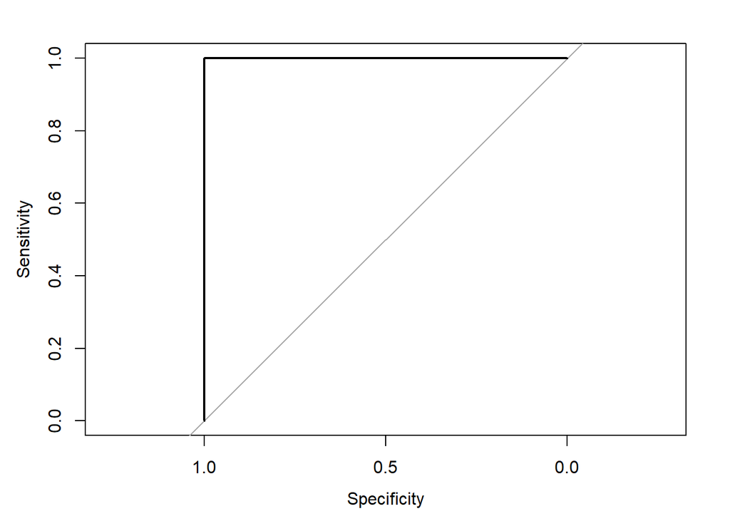

```r
prob <- predict(fit_knn_wtd, newdata = auto2_wtd, type = "prob")[,2]
myRoc <- roc(auto2_wtd$honda, prob)
plot(myRoc)
```

```r
auc(myRoc)
```

```
Area under the curve: 1
```

> TODO: *With an AOC of 1, this model is nearly perfect, likely because of how heavily weighted it is. There are actually few hondas in the dataset, making the weight of 29.15 extremely high. It would be concerning if the model was inaccurate under these circumstances.*